# FINANCIAL ECONOMETRICS Summer Semester 2023

## EMPIRICAL PROJECT

### Authors: Tomáš Bajcár, Karolína Hozová

### Author's emails: 37665566@fsv.cuni.cz, 59645240@fsv.cuni.cz

In this empirical project, stock analysis for Archer-Daniels-Midland Co. (ADM) will be performed. Archer-Daniels-Midland Company is an American multinational corporation focusing on food processing and commodities trading. Established in 1902 and based in Chicago, Illinois, ADM holds a prominent position in the industry. It secured the 38th spot on the Fortune 500 list of the largest US corporations in 2022. ADM is listed on NASDAQ.

```r
install.packages('tseries')
install.packages('data.table')
install.packages('aod')
install.packages('zoo')
install.packages('xts')
install.packages('forecast')
install.packages('aTSA')
install.packages('car')
install.packages('rugarch')


library('tseries')
library('data.table')
library("aod")
library('zoo')
library('xts')
library('forecast')
library('aTSA')
library("car")
library('rugarch')
```

## 1. Data description

In this section, a short summary of descriptive statistics will be provided, as well as ACF plots and other handful plots of the data. The data consist of returns, realized volatility, positive realized semi-volatility, negative realized semi-volatility, realized skewness and realized kurtosis over sample period 05.01.2010 - 22.01.2016.

```r
data <- load('11.RData')
```

```r
summary(adm) #quick glance what to expect
```

```
     Index                 ret                   RV
 Min.   :2010-01-05   Min.   :-0.1065924   Min.   :0.004101
 1st Qu.:2011-07-04   1st Qu.:-0.0080189   1st Qu.:0.008730
 Median :2013-01-10   Median : 0.0000000   Median :0.010624
 Mean   :2013-01-08   Mean   : 0.0001104   Mean   :0.011454
 3rd Qu.:2014-07-14   3rd Qu.: 0.0085580   3rd Qu.:0.013006
 Max.   :2016-01-22   Max.   : 0.0582577   Max.   :0.040228
      RV_p               RV_n                RS                 RK
 Min.   :0.002636   Min.   :0.002392   Min.   :-7.02623   Min.   : 2.162
 1st Qu.:0.006096   1st Qu.:0.005877   1st Qu.:-0.56551   1st Qu.: 3.506
 Median :0.007395   Median :0.007348   Median : 0.03201   Median : 4.591
 Mean   :0.008016   Mean   :0.008007   Mean   : 0.02307   Mean   : 6.037
 3rd Qu.:0.009144   3rd Qu.:0.009297   3rd Qu.: 0.60863   3rd Qu.: 6.598
 Max.   :0.033750   Max.   :0.033103   Max.   : 6.10468   Max.   :57.747
```

### A. Returns

```r
summary(adm$ret)
```

```
     Index                 ret
 Min.   :2010-01-05   Min.   :-0.1065924
 1st Qu.:2011-07-04   1st Qu.:-0.0080189
 Median :2013-01-10   Median : 0.0000000
 Mean   :2013-01-08   Mean   : 0.0001104
 3rd Qu.:2014-07-14   3rd Qu.: 0.0085580
 Max.   :2016-01-22   Max.   : 0.0582577
```

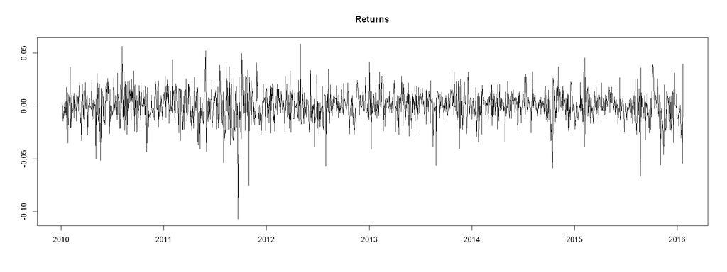

```r
options(repr.plot.width = 16, repr.plot.height = 6)
plot.zoo(adm$ret,xlab=NA,ylab=NA, main="Returns")
```

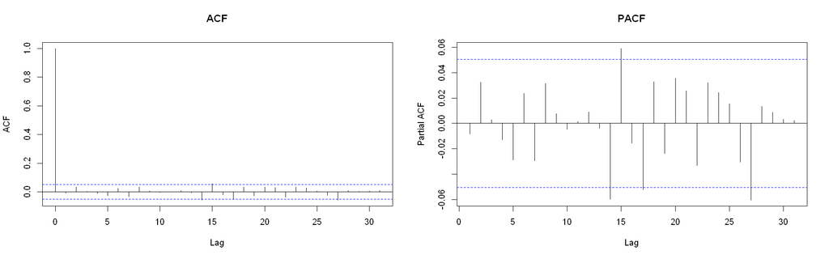

```r
options(repr.plot.width = 16, repr.plot.height = 5)
par(mfrow = c(1, 2))
acf(adm$ret, main="ACF")
pacf(adm$ret, main="PACF")
```

```r
tseries::adf.test(adm$ret)
```

```
	Augmented Dickey-Fuller Test

data:  adm$ret
Dickey-Fuller = -10.848, Lag order = 11, p-value = 0.01
alternative hypothesis: stationary
```

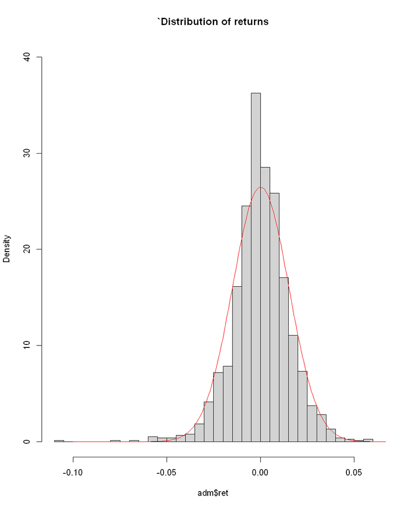

```r
options(repr.plot.width = 8, repr.plot.height = 10)
hist(adm$ret, 35, probability=T, ylim=c(0,40),main="`Distribution of returns")
x <- seq(-0.10, 0.10, by = .001)
lines(x, dnorm(x, mean(adm$ret), sd(adm$ret)), col="red")
```

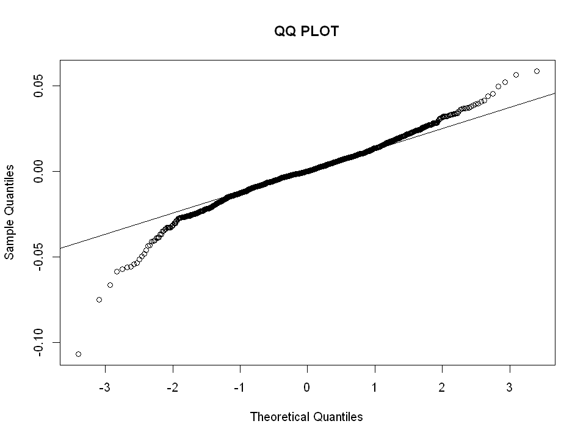

```r
options(repr.plot.width = 8, repr.plot.height = 6)
qqnorm(adm$ret, main='QQ PLOT')
qqline(adm$ret)
```

### B. Realized volatility, positive realized semi-volatility, negative realized semi-volatility

The summary below gives insights into the historical patterns of realized volatility during the specified time period. Returns of the ADM stock experienced fluctuations around the mean value of 0.011 given the sample period. Mean and median values of positive and negative realized semi-volatility are quite similar, even though for the given sample the positive RV is on average a bit higher, which is also visible from the graph. As we can see from the correlograms, ACF is decaying very slowly, which might indicate non-stationarity and/or long memory. PACF decays faster, but there are some significant lags, especially for the negative realized semi-volatility.

```r
summary(adm$RV)
summary(adm$RV_p)
summary(adm$RV_n)
```

```
     Index                  RV
 Min.   :2010-01-05   Min.   :0.004101
 1st Qu.:2011-07-04   1st Qu.:0.008730
 Median :2013-01-10   Median :0.010624
 Mean   :2013-01-08   Mean   :0.011454
 3rd Qu.:2014-07-14   3rd Qu.:0.013006
 Max.   :2016-01-22   Max.   :0.040228
```

```
     Index                 RV_p
 Min.   :2010-01-05   Min.   :0.002636
 1st Qu.:2011-07-04   1st Qu.:0.006096
 Median :2013-01-10   Median :0.007395
 Mean   :2013-01-08   Mean   :0.008016
 3rd Qu.:2014-07-14   3rd Qu.:0.009144
 Max.   :2016-01-22   Max.   :0.033750
```

```
     Index                 RV_n
 Min.   :2010-01-05   Min.   :0.002392
 1st Qu.:2011-07-04   1st Qu.:0.005877
 Median :2013-01-10   Median :0.007348
 Mean   :2013-01-08   Mean   :0.008007
 3rd Qu.:2014-07-14   3rd Qu.:0.009297
 Max.   :2016-01-22   Max.   :0.033103
```

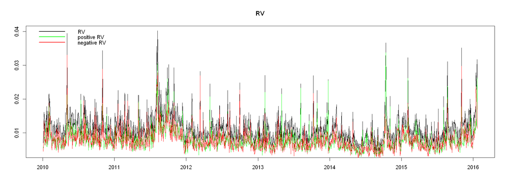

```r
options(repr.plot.width = 16, repr.plot.height = 6)
plot.zoo(adm$RV,xlab=NA,ylab=NA, main="RV")
lines(zoo(adm$RV_p),col="green", lwd=1)
lines(zoo(adm$RV_n),col="red", lwd=1)

legend("topleft", ncol = 1, legend = c('RV', 'positive RV', 'negative RV'),
       col = c('black', 'green', 'red'), lwd = 2, bty = 'n')
```

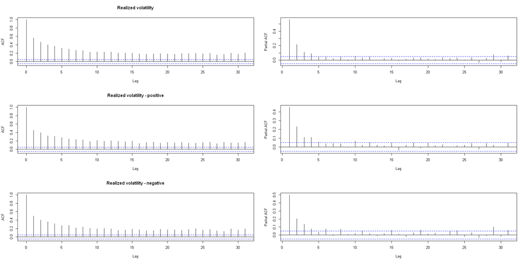

```r
options(repr.plot.width = 16, repr.plot.height = 8)
par(mfrow = c(3, 2))
acf(adm$RV, main="Realized volatility")
pacf(adm$RV, main="")
acf(adm$RV_p, main="Realized volatility - positive")
pacf(adm$RV_p, main="")
acf(adm$RV_n, main="Realized volatility - negative")
pacf(adm$RV_n, main="")
```

### C. Realized skewness and realized kurtosis

A mean value of kurtosis 6.037 suggests that the distribution of RV has a relatively high peak and heavy tails compared to a normal distribution. It indicates that the data has a greater concentration of values around the mean and more extreme values in the tails compared to a normal distribution, as it was already suggested in the histogram of returns. Thus, there is a higher probability of extreme events or outliers occurring. When we look at kurtosis through a different optic - as volatility of volatility - we see that RV fluctuates over time, which is also visible from initial graph. A mean skewness value of 0.02307 suggests that the distribution is approximately symmetric. A skewness value of zero would indicate perfect symmetry, but in our case a small positive skewness suggests a slight imbalance in the distribution, namely right-skewed distribution with the long tail on its right side. In the context of asset returns, a right-skewed distribution suggests that there is a higher probability of observing positive or higher returns compared to negative or lower returns. Overall, realised skewness is in line with expectations as it is centered around zero and resembles white noise, i.e. there is no free lunch.

```r
summary(adm$RS)
summary(adm$RK)
```

```
     Index                  RS
 Min.   :2010-01-05   Min.   :-7.02623
 1st Qu.:2011-07-04   1st Qu.:-0.56551
 Median :2013-01-10   Median : 0.03201
 Mean   :2013-01-08   Mean   : 0.02307
 3rd Qu.:2014-07-14   3rd Qu.: 0.60863
 Max.   :2016-01-22   Max.   : 6.10468
```

```
     Index                  RK
 Min.   :2010-01-05   Min.   : 2.162
 1st Qu.:2011-07-04   1st Qu.: 3.506
 Median :2013-01-10   Median : 4.591
 Mean   :2013-01-08   Mean   : 6.037
 3rd Qu.:2014-07-14   3rd Qu.: 6.598
 Max.   :2016-01-22   Max.   :57.747
```

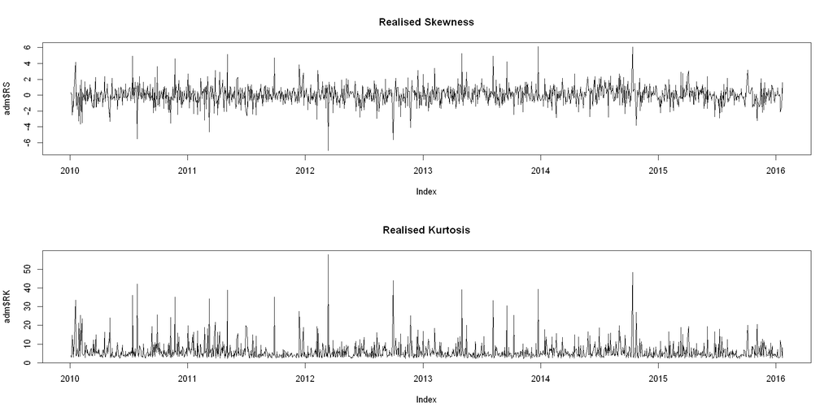

```r
options(repr.plot.width = 16, repr.plot.height = 8)
par(mfrow = c(2,1))
plot.zoo(adm$RS, main="Realised Skewness")
plot.zoo(adm$RK, main="Realised Kurtosis")
```

## 2. In-sample fit

In this section, parameters of the following volatility models of the full sample size will be estimated: AR(1)-RV, HAR, HAR-RS, HAR-Rskew-RKurt, Realized GARCH, ARMA-GARCH. We start with creating lag of all the variables.

```r
adm$RV_lag <- shift(adm$RV)
adm$RV5_lag <- frollmean(adm$RV_lag, 5)
adm$RV22_lag <- frollmean(adm$RV_lag, 22)
adm$RV_p_lag <- shift(adm$RV_p)
adm$RV_n_lag <- shift(adm$RV_n)
adm$RS_lag <- shift(adm$RS)
adm$RK_lag <- shift(adm$RK)
```

### A. AR(1)-RV

We start with estimation of the first-order autoregressive model, that has the following form:

$$RV_t = \alpha + \beta * RV_{t-1} + \epsilon_t$$

Thre intuition behind this model is that the realized volatility (RV) in time t depends linearly on its own previous value in time t-1. From the below estimated output is it visible that this holds as the estimated coefficient on RV_lag is significantly positive. However, it might be beneficial to extend the model for other lags, or used another model. This is suggested also by ACF and PACF of residuals which show some significant lags meaning we are still dealing with the dependence. However, since ACF of RV shows slow decay, RV might follow more complicated process and so AR(1) cannot be a good fit.

```r
AR1_RV <- lm(RV ~ RV_lag, data=adm, na.action=na.omit)
summary(AR1_RV)
```

```
Call:
lm(formula = RV ~ RV_lag, data = adm, na.action = na.omit)

Residuals:
       Min         1Q     Median         3Q        Max
-0.0118405 -0.0020537 -0.0005858  0.0013967  0.0252933

Coefficients:
             Estimate Std. Error t value Pr(>|t|)
(Intercept) 0.0050177  0.0002608   19.24   <2e-16 ***
RV_lag      0.5623672  0.0213796   26.30   <2e-16 ***
---
Signif. codes:  0 '***' 0.001 '**' 0.01 '*' 0.05 '.' 0.1 ' ' 1

Residual standard error: 0.003486 on 1497 degrees of freedom
  (1 observation deleted due to missingness)
Multiple R-squared:  0.3161,	Adjusted R-squared:  0.3156
F-statistic: 691.9 on 1 and 1497 DF,  p-value: < 2.2e-16
```

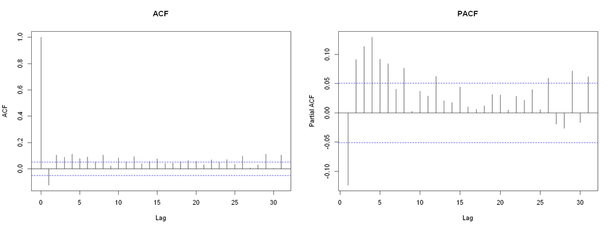

```r
options(repr.plot.width = 16, repr.plot.height = 6)
par(mfrow = c(1, 2))
acf(AR1_RV$residuals, main = 'ACF')
pacf(AR1_RV$residuals, main  = 'PACF')
```

### 2. HAR

Since AR(1)-RV has been proven as not very good fit for the data and the long memory is suspected, heterogeneous autoregressive model (HAR) is employed. Its form is depicted as:

$$RV_t = \alpha + \beta_1 * RV_{t-1} + \beta_2 * RV_{t-1}^{(5)} + \beta_3 * RV_{t-1}^{(22)} + \epsilon_t$$

where $RV_{t-1}^{(h)}$ is h-period realized volatility. The main idea behind the HAR model is based on different behavior of investors, hence term "heterogeneous". The behavior is captured by different investment horizons of traders, 1-day, 5-days (week) and 22-days (month).

From the model depicted below we can see that the estimated coefficients on 1-day, 5-days and 22-days realized volatilities are all significant and positive. This suggests that AR(1) process from previous part is not a good fit since more distant lags are significant as well. Improvement in comparison to the simple AR(1) model is suggested also by a bit higher R-squared and less significant lags in ACF and PACF correlograms. However, significant lags are still present (albeit marginally) and R-squared has not improved by much, thus extensions of HAR or other models might be handy.

```r
HAR <- lm(RV ~ RV_lag + RV5_lag + RV22_lag, data=adm)
summary(HAR)
```

```
Call:
lm(formula = RV ~ RV_lag + RV5_lag + RV22_lag, data = adm)

Residuals:
       Min         1Q     Median         3Q        Max
-0.0101442 -0.0019376 -0.0005605  0.0012050  0.0251088

Coefficients:
             Estimate Std. Error t value Pr(>|t|)
(Intercept) 0.0018877  0.0004163   4.535 6.23e-06 ***
RV_lag      0.3319826  0.0306291  10.839  < 2e-16 ***
RV5_lag     0.3084857  0.0510944   6.038 1.98e-09 ***
RV22_lag    0.1951805  0.0527747   3.698 0.000225 ***
---
Signif. codes:  0 '***' 0.001 '**' 0.01 '*' 0.05 '.' 0.1 ' ' 1

Residual standard error: 0.003348 on 1474 degrees of freedom
  (22 observations deleted due to missingness)
Multiple R-squared:   0.37,	Adjusted R-squared:  0.3687
F-statistic: 288.6 on 3 and 1474 DF,  p-value: < 2.2e-16
```

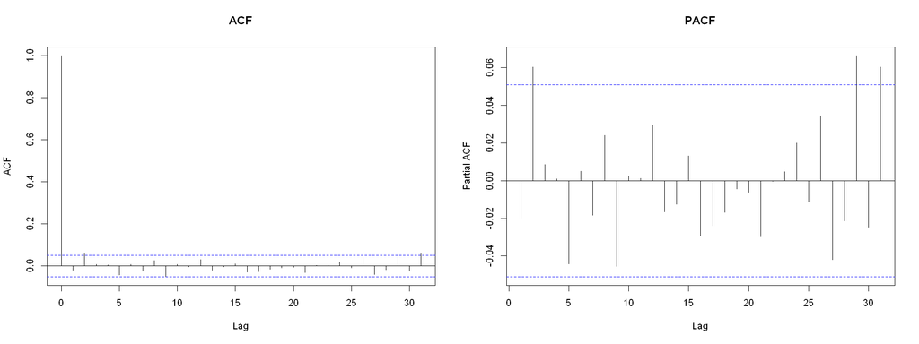

```r
par(mfrow = c(1, 2))
acf(HAR$residuals, main = 'ACF')
pacf(HAR$residuals, main = 'PACF')
```

### 3. HAR-RS

Since $RV_t=RV^+_{t}+RV^-_{t}$, including $RV^+_{t-1}+RV^-_{t-1}$ instead of $RV_{t-1}$ can depict the effect of "bad" and "good" volatility separately. Thus, this variation of heterogeneous autoregressive model will take following form:

$$RV_t = \alpha + \beta_0 * RV^+_{t-1} + \beta_1 * RV^-_{t-1} + \beta_2 * RV_{t-1}^{(5)} + \beta_3 * RV_{t-1}^{(22)} + \epsilon_t$$

From the output below it is clear that past "bad" volatility increases volatility more than past "good" volatility, which is in line with empirical findings. Correlograms of ACF and PACF look very similar to the previous ones.

```r
HAR_RS <- lm(RV ~ RV_p_lag + RV_n_lag + RV5_lag + RV22_lag, data=adm)
summary(HAR_RS)
```

```
Call:
lm(formula = RV ~ RV_p_lag + RV_n_lag + RV5_lag + RV22_lag, data = adm)

Residuals:
       Min         1Q     Median         3Q        Max
-0.0102407 -0.0019412 -0.0005483  0.0011566  0.0251997

Coefficients:
             Estimate Std. Error t value Pr(>|t|)
(Intercept) 0.0019021  0.0004138   4.597 4.66e-06 ***
RV_p_lag    0.1362320  0.0404098   3.371 0.000768 ***
RV_n_lag    0.3532866  0.0376775   9.377  < 2e-16 ***
RV5_lag     0.3028505  0.0510146   5.937 3.62e-09 ***
RV22_lag    0.1892819  0.0524404   3.609 0.000317 ***
---
Signif. codes:  0 '***' 0.001 '**' 0.01 '*' 0.05 '.' 0.1 ' ' 1

Residual standard error: 0.003328 on 1473 degrees of freedom
  (22 observations deleted due to missingness)
Multiple R-squared:  0.3778,	Adjusted R-squared:  0.3761
F-statistic: 223.6 on 4 and 1473 DF,  p-value: < 2.2e-16
```

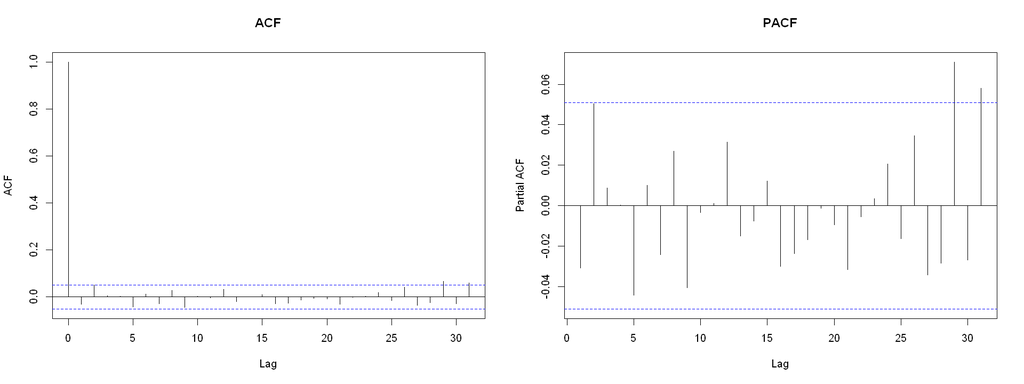

```r
par(mfrow = c(1, 2))
acf(HAR_RS$residuals, main = 'ACF')
pacf(HAR_RS$residuals, main = 'PACF')
```

### 4. HAR-RSkew-RKurt

Another possibility is to extend the standard HAR for realized skewness and realized kurtosis. Such a model will be estimated as:

$$RV_t = \alpha + \beta_1 * RV_{t-1} + \beta_2 * RV_{t-1}^{(5)} + \beta_3 * RV_{t-1}^{(22)} + \beta_4 * RSkew_{t-1} + \beta_5 * RKurt_{t-1} + \epsilon_t$$

```r
HAR_RS_RK <- lm(RV ~ RV_lag + RV5_lag + RV22_lag + RS_lag + RK_lag, data=adm)
summary(HAR_RS_RK)
```

```
Call:
lm(formula = RV ~ RV_lag + RV5_lag + RV22_lag + RS_lag + RK_lag,
    data = adm)

Residuals:
       Min         1Q     Median         3Q        Max
-0.0099033 -0.0019170 -0.0005703  0.0011678  0.0249877

Coefficients:
              Estimate Std. Error t value Pr(>|t|)
(Intercept)  2.662e-03  4.279e-04   6.221 6.42e-10 ***
RV_lag       4.198e-01  3.363e-02  12.483  < 2e-16 ***
RV5_lag      2.575e-01  5.114e-02   5.034 5.39e-07 ***
RV22_lag     1.565e-01  5.237e-02   2.989  0.00284 **
RS_lag      -1.569e-04  7.746e-05  -2.026  0.04300 *
RK_lag      -1.252e-04  2.024e-05  -6.185 8.01e-10 ***
---
Signif. codes:  0 '***' 0.001 '**' 0.01 '*' 0.05 '.' 0.1 ' ' 1

Residual standard error: 0.003301 on 1472 degrees of freedom
  (22 observations deleted due to missingness)
Multiple R-squared:  0.3886,	Adjusted R-squared:  0.3865
F-statistic: 187.1 on 5 and 1472 DF,  p-value: < 2.2e-16
```

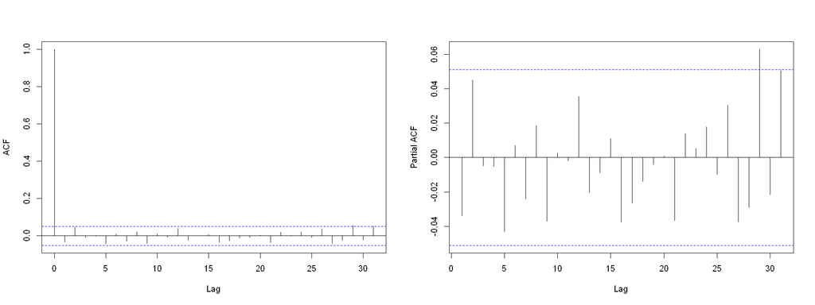

```r
par(mfrow = c(1, 2))
acf(HAR_RS_RK$residuals, main = NA)
pacf(HAR_RS_RK$residuals, main = NA)
```

### 5. ARMA-GARCH

In order to estimate GARCH model, mean equation needs to be specified. Using selection procedure based on Akaike information criterion (AIC) and Bayesian Information Criteria (BIC), ARMA(0,0) is reported to be the best fit indicating that there is no autoregressive, differencing, or moving average component included in the mean equation. Thus, this mean equation has the following form:

$$r_{t}=c+\epsilon_{t}$$

where c is some constant.

Homoscedasticity of the residuals at the lowest lags is rejected by employing ARCH-LM test. Jarque-Bera test is applied to test normality of model’s residuals. The test rejects the null hypothesis of normality at any commonly used level of significance, signalling conditional heteroskedasticity being present in the data. Thus, we model ARMA-GARCH to account for it. Standard GARCH is used given by:

$$\sigma^2_{t}=\omega+\sum_{i=1}^{p}\alpha_{i}u^2_{t-i}+\sum_{j=1}^{q} \beta_{j}\sigma^2_{t-j}$$

ARMA(0,0)-GARCH(1,1) is shown to be the best fit for the data, minimizing the BIC (various models up to GARCH(5,5) has been tested). As per results of the model estimation, $\omega$ is the constant term in the conditional variance equation and represents the long-run average variance. Positive value of $\alpha$ indicates that past squared errors have a positive effect on the current variance. $\beta$ parameter measures the persistence of the conditional variance. It is close to 1 which means that shocks to the variance are long-lasting and take a long time to dissipate. There are no signs of bias which suggests that there should not be leverage effect present. We moreover tested null hypothesis of Weighted ARCH LM Test which suggests that the ARCH process is adequately fitted. The results indicate that the null hypothesis cannot be rejected at all commonly used levels of significance.

```r
(fit_auto <- auto.arima(adm$ret, ic = c("bic"), stationary = TRUE))
```

```
Series: adm$ret
ARIMA(0,0,0) with zero mean

sigma^2 = 0.000227:  log likelihood = 4164.61
AIC=-8327.21   AICc=-8327.21   BIC=-8321.9
```

```
ARCH heteroscedasticity test for residuals
alternative: heteroscedastic

Portmanteau-Q test:
     order    PQ  p.value
[1,]     4  33.5 9.55e-07
[2,]     8  56.5 2.25e-09
[3,]    12  66.5 1.42e-09
[4,]    16  72.5 3.65e-09
[5,]    20  93.2 2.05e-11
[6,]    24 101.8 1.46e-11
Lagrange-Multiplier test:
     order   LM p.value
[1,]     4 1388       0
[2,]     8  669       0
[3,]    12  425       0
[4,]    16  315       0
[5,]    20  240       0
[6,]    24  197       0
```

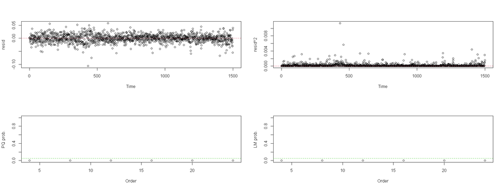

```r
arima00 <- arima(adm$ret, order = c(0, 0, 0))
arch.test(arima00)
```

```r
jarque.bera.test(arima00$residual)
```

```
	Jarque Bera Test

data:  arima00$residual
X-squared = 686.43, df = 2, p-value < 2.2e-16
```

```r
# find the best GARCH model based on the BIC
p_max <- 5
q_max <- 5
aic_min <- Inf
best_p <- 0
best_q <- 0

for (i1 in 1:p_max) {
    for (i2 in 1:q_max) {
        garchspec <- ugarchspec(mean.model = list(armaOrder = c(0, 0), include.mean = TRUE),
                     variance.model = list(model = 'sGARCH', garchOrder = c(i1, i2)))
        garch_fit <- ugarchfit(spec = garchspec, data = adm$ret)
        inf_crit <- infocriteria(garch_fit)[2] #1 aic, 2 bic
        aic_min <- ifelse(inf_crit < aic_min, inf_crit, aic_min)

        best_p <- ifelse(inf_crit == aic_min, i1, best_p)
        best_q <- ifelse(inf_crit == aic_min, i2, best_q)
    }
}

c(best_p, best_q)

# specify the model that we want to estimate
garchspec <- ugarchspec(mean.model = list(armaOrder = c(0, 0), include.mean = TRUE),
                     variance.model = list(garchOrder = c(best_p, best_q)))
# estimate the model
garch_fit <- ugarchfit(spec = garchspec, data = adm$ret)
garch_fit
```

1. 1

2. 1

```
*---------------------------------*
*          GARCH Model Fit        *
*---------------------------------*

Conditional Variance Dynamics
-----------------------------------
GARCH Model	: sGARCH(1,1)
Mean Model	: ARFIMA(0,0,0)
Distribution	: norm

Optimal Parameters
------------------------------------
        Estimate  Std. Error  t value Pr(>|t|)
mu      0.000504    0.000357   1.4144  0.15725
omega   0.000011    0.000001  20.2979  0.00000
alpha1  0.085348    0.008295  10.2887  0.00000
beta1   0.872276    0.012049  72.3969  0.00000

Robust Standard Errors:
        Estimate  Std. Error  t value Pr(>|t|)
mu      0.000504    0.000381   1.3224  0.18604
omega   0.000011    0.000001  14.0805  0.00000
alpha1  0.085348    0.011449   7.4546  0.00000
beta1   0.872276    0.016464  52.9799  0.00000

LogLikelihood : 4218.755

Information Criteria
------------------------------------

Akaike       -5.6197
Bayes        -5.6055
Shibata      -5.6197
Hannan-Quinn -5.6144

Weighted Ljung-Box Test on Standardized Residuals
------------------------------------
                        statistic p-value
Lag[1]                    0.01875  0.8911
Lag[2*(p+q)+(p+q)-1][2]   1.75446  0.3070
```

[output cut: 36 more lines]

```
Negative Sign Bias 1.14744 0.2514
Positive Sign Bias 0.09914 0.9210
Joint Effect       2.71408 0.4378


Adjusted Pearson Goodness-of-Fit Test:
------------------------------------
  group statistic p-value(g-1)
1    20     53.79    3.559e-05
2    30     66.92    7.905e-05
3    40     82.72    5.568e-05
4    50    107.27    3.084e-06


Elapsed time : 0.252584
```

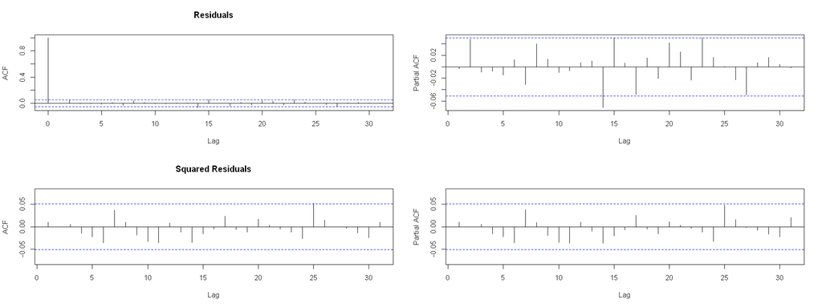

```r
res_garch_fit <- residuals(garch_fit, standardize = TRUE)

par(mfrow=c(2,2))
acf(res_garch_fit, main = "Residuals")
pacf(res_garch_fit, main="")

Acf(res_garch_fit ** 2, main="Squared Residuals")
Pacf(res_garch_fit ** 2, main="")
```

### 6. Realized GARCH

Since GARCH takes information from returns to adjust value of conditional variance but is updating slowly, using realized GARCH that includes realized volatility in the volatility equation can come in handy. Using realized GARCH may hugely improve the fit. Thus, complete realized GARCH takes form:

\begin{align} r_t= & \sqrt{h_t}z_t \\ ln(h_t)= & \omega + \beta ln(h_{t-1})+\alpha ln(RV_{t-1})\\ ln(RV_t)= & \xi+ \varphi ln(h_t) + u_t \end{align}

ARMA(0,0)-realGARCH(1,1) is estimated with BIC lower than in the standard GARCH.

```r
real_garchspec<- ugarchspec(variance.model = list(model = 'realGARCH', garchOrder = c(1, 1)),
    mean.model = list(armaOrder=c(0, 0), include.mean=FALSE))
real_garch_fit<- ugarchfit(real_garchspec, adm$ret, solver = 'gosolnp', realizedVol = sqrt(adm$RV))
real_garch_fit
```

```
*---------------------------------*
*          GARCH Model Fit        *
*---------------------------------*

Conditional Variance Dynamics
-----------------------------------
GARCH Model	: realGARCH(1,1)
Mean Model	: ARFIMA(0,0,0)
Distribution	: norm

Optimal Parameters
------------------------------------
        Estimate  Std. Error  t value Pr(>|t|)
omega  -0.318284    0.205775 -1.54676  0.12192
alpha1  1.000000    0.105808  9.45111  0.00000
beta1   0.697830    0.023947 29.14006  0.00000
eta11  -0.016967    0.003143 -5.39810  0.00000
eta21   0.015143    0.001770  8.55651  0.00000
delta   0.246760    0.021685 11.37906  0.00000
lambda  0.119122    0.002178 54.69204  0.00000
xi     -0.154010    0.183939 -0.83729  0.40243

Robust Standard Errors:
        Estimate  Std. Error  t value Pr(>|t|)
omega  -0.318284    0.330514 -0.96300 0.335548
alpha1  1.000000    0.154342  6.47910 0.000000
beta1   0.697830    0.028273 24.68226 0.000000
eta11  -0.016967    0.003550 -4.77963 0.000002
eta21   0.015143    0.002757  5.49281 0.000000
delta   0.246760    0.031637  7.79976 0.000000
lambda  0.119122    0.002829 42.10100 0.000000
xi     -0.154010    0.270105 -0.57019 0.568552

LogLikelihood : 5344.594

Information Criteria
------------------------------------

Akaike       -7.1155
Bayes        -7.0871
```

[output cut: 48 more lines]

```
Negative Sign Bias  2.1360 0.03284  **
Positive Sign Bias  0.4856 0.62730
Joint Effect        5.0700 0.16674


Adjusted Pearson Goodness-of-Fit Test:
------------------------------------
  group statistic p-value(g-1)
1    20     33.36     0.021840
2    30     51.16     0.006753
3    40     63.68     0.007554
4    50     79.33     0.003937


Elapsed time : 2.350508
```

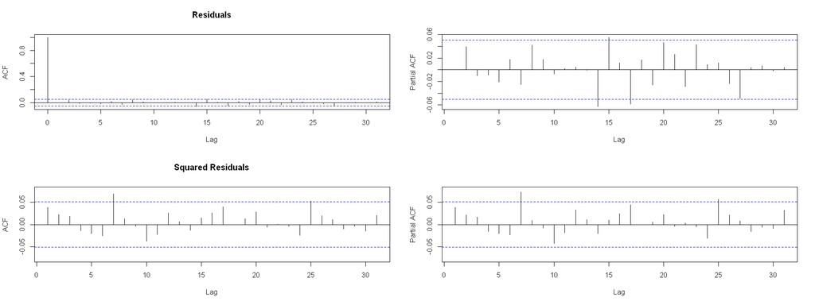

```r
res_real_garch_fit <- residuals(real_garch_fit, standardize = TRUE)

par(mfrow=c(2,2))
acf(res_real_garch_fit, main = "Residuals")
pacf(res_real_garch_fit, main="")

Acf(res_real_garch_fit ** 2, main="Squared Residuals")
Pacf(res_real_garch_fit ** 2, main="")
```

## Comparison of the models

Finally, we compare invidiual models visually.

We start with AR(1) and HAR models. From the figures below, we see that AR(1) model is more noisy than HAR models and that it inflates true volatility proxied by RV. This is applicable to some periods. Neverthless, superiority of the models is attributed to HAR family. The fits are generally very similar to each other. We expect this since the models yield similar estimates and showed similar characteristics.

```r
AR1_RV_fit <- xts(fitted(AR1_RV), order.by=as.Date(names(fitted(AR1_RV))))
HAR_fit <- xts(fitted(HAR), order.by=as.Date(names(fitted(HAR))))
HAR_RS_fit <- xts(fitted(HAR_RS), order.by=as.Date(names(fitted(HAR_RS))))
HAR_RS_RK_fit <- xts(fitted(HAR_RS_RK), order.by=as.Date(names(fitted(HAR_RS_RK))))
```

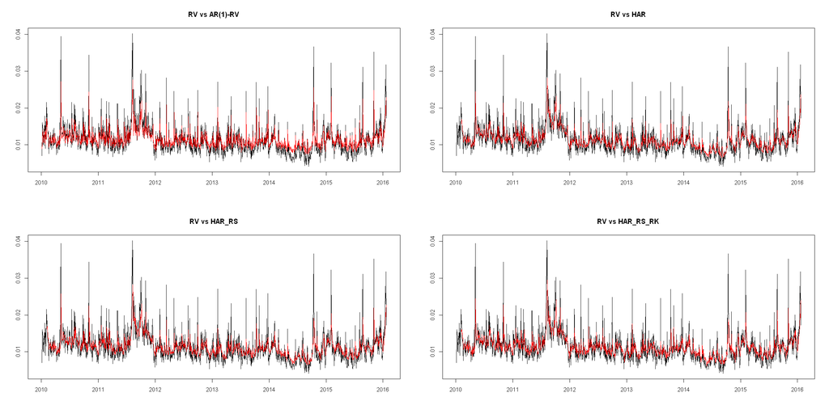

```r
options(repr.plot.width = 20, repr.plot.height = 10)

par(mfrow = c(2, 2))

plot.zoo(adm$RV, col="black", xlab=NA,ylab=NA, main="RV vs AR(1)-RV")
lines(zoo(AR1_RV_fit), col="red")

plot.zoo(adm$RV, col="black", xlab=NA,ylab=NA, main="RV vs HAR")
lines(zoo(HAR_fit), col="red")

plot.zoo(adm$RV, col="black", xlab=NA,ylab=NA, main="RV vs HAR_RS")
lines(zoo(HAR_RS_fit), col="red")

plot.zoo(adm$RV, col="black", xlab=NA,ylab=NA, main="RV vs HAR_RS_RK")
lines(zoo(HAR_RS_RK_fit), col="red")
```

Let's try to plot RV with GARCH and Realized GARCH in one figure. We see that classical GARCH overestimates RV more than Realized GARCH. Nevertheless, neither of the models seem to capture RV sufficiently. This is by the construction as GARCH models volatility as a latent process and behaves like a filter. Overall, HAR models outperform GARCH models as well.

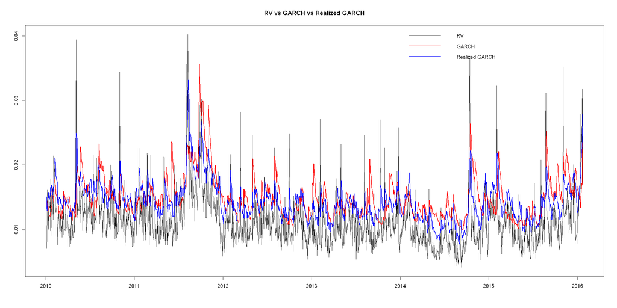

```r
options(repr.plot.width = 20, repr.plot.height = 10)
plot.zoo(adm$RV,xlab=NA,ylab=NA, main = "RV vs GARCH vs Realized GARCH")
lines(zoo(sigma(garch_fit)),col="red", lwd = 2)
lines(zoo(sigma(real_garch_fit)),col="blue", lwd = 2)
legend("topright", ncol = 1, legend = c('RV', 'GARCH', 'Realized GARCH'), col = c('black', 'red', 'blue'), lwd = 2, bty = 'n')
```

## 3. Forecasts

In this section, we proceed with forecasts of volatility based on the models specificed above. As suggested, initial window length is set to 750 observations. Total number of observations is 1500, so the second 750 observations is the testing set. For AR(1) and HAR models we do not follow seminar 11 but rather use simple predict() function. This is driven by the fact that we work with more complex HAR models. Plots of individual forecasts are visualized after all models are taken care of.

### AR(1) and HAR models - rolling & expanding

In the beginning, we specify the window length and number of forecast outputs. Then we set aside true RV so we can compare our forecasts to it. Finally, we prepare an object of logical values which we will replace by the forecast. We have tried to create a list object for each item as well but that turned out to be rather clumsy.

```r
w_l <- 750
n_for <- 750
RV_true <- adm$RV[751:1500]

start <- 1
end <- 750
AR1_exp <- rep(NA, 750)
AR1_roll <- rep(NA, 750)
HAR_exp <- rep(NA, 750)
HAR_roll <- rep(NA, 750)
HAR_RS_exp <- rep(NA, 750)
HAR_RS_roll <- rep(NA, 750)
HAR_RS_RK_exp <- rep(NA, 750)
HAR_RS_RK_roll <- rep(NA, 750)
```

We start with rolling window. Simply for each model specification, we shift the window and save a newly forecast value. We proceed analogically with expanding window below. This time, however, training set is altered so it really is expanding.

```r
# rolling
for (i in 0:(750-1)) {
    training <- adm[(start + i):(end + i), ]
    testing <- adm[end + i + 1,]

    AR1_RV <- lm(RV ~ RV_lag, data=training)
    AR1_roll[i + 1] <- predict(AR1_RV, newdata=testing)

    HAR <- lm(RV ~ RV_lag + RV5_lag + RV22_lag, data=training)
    HAR_roll[i + 1] <- predict(HAR, newdata=testing)

    HAR_RS <- lm(RV ~ RV_p_lag + RV_n_lag + RV5_lag + RV22_lag, data=training)
    HAR_RS_roll[i + 1] <- predict(HAR_RS, newdata=testing)

    HAR_RS_RK <- lm(RV ~ RV_lag + RV5_lag + RV22_lag + RS_lag + RK_lag, data=training)
    HAR_RS_RK_roll[i + 1] <- predict(HAR_RS_RK, newdata=testing)
}
```

```r
# expanding
for (i in 0:(750-1)) {
    training <- adm[start:(end + i), ]
    testing <- adm[end + i + 1,]

    AR1_RV <- lm(RV ~ RV_lag, data=training)
    AR1_exp[i + 1] <- predict(AR1_RV, newdata=testing)

    HAR <- lm(RV ~ RV_lag + RV5_lag + RV22_lag, data=training)
    HAR_exp[i + 1] <- predict(HAR, newdata=testing)

    HAR_RS <- lm(RV ~ RV_p_lag + RV_n_lag + RV5_lag + RV22_lag, data=training)
    HAR_RS_exp[i + 1] <- predict(HAR_RS, newdata=testing)

    HAR_RS_RK <- lm(RV ~ RV_lag + RV5_lag + RV22_lag + RS_lag + RK_lag, data=training)
    HAR_RS_RK_exp[i + 1] <- predict(HAR_RS_RK, newdata=testing)
}
```

### ARMA-GARCH Model - rolling & expanding

Regarding ARMA-GARCH we follow the code from the seminar.

```r
GARCH_roll_exp<-list()

system.time(
GARCH_roll_exp[[1]]<-ugarchroll(garchspec, adm$ret, n.ahead = 1, forecast.length = n_for,
                                 n.start = NULL, refit.every = 1, refit.window = c("moving"),
                                 window.size = w_l, solver = "solnp", fit.control = list(),
                                 solver.control = list(), calculate.VaR = FALSE,
                                 cluster = NULL, keep.coef = TRUE)
)

system.time(
GARCH_roll_exp[[2]]<-ugarchroll(garchspec, adm$ret, n.ahead = 1, forecast.length = n_for,
                                n.start = NULL, refit.every = 1, refit.window = c("recursive"),
                                window.size = w_l, solver = "solnp", fit.control = list(),
                                solver.control = list(), calculate.VaR = FALSE,
                                cluster = NULL, keep.coef = TRUE)
)
```

```
   user  system elapsed
 257.14    3.89  265.64
```

```
   user  system elapsed
 310.64    3.74  322.13
```

```r
sigma_GARCH_roll_for <- GARCH_roll_exp[[1]]@forecast$density$Sigma
sigma_GARCH_exp_for <- GARCH_roll_exp[[2]]@forecast$density$Sigma
```

### Realized GARCH - rolling and expanding

```r
system.time(
real_GARCH_roll<-ugarchroll(real_garchspec, adm$ret, n.ahead = 1, forecast.length = n_for,
                            n.start = NULL, refit.every = 1, refit.window = c("moving"),
                            window.size = w_l, solver = "gosolnp", fit.control = list(),
                            solver.control = list(), calculate.VaR = FALSE,
                            cluster = NULL, keep.coef = FALSE,realizedVol = sqrt(adm$RV))
)
```

[output not shown]

[output cut: 235 more lines]

[output not shown]

```
   user  system elapsed
 919.03    8.52  955.58
```

```r
real_GARCH_roll_1 <- resume(real_GARCH_roll, solver = "gosolnp")
```

```r
real_GARCH_roll_2 <- resume(real_GARCH_roll_1, solver = "gosolnp")
```

```r
sigma_real_GARCH_roll_for <- real_GARCH_roll_2@forecast[["density"]]$Sigma
```

```r
system.time(
real_GARCH_exp<-ugarchroll(real_garchspec, adm$ret, n.ahead = 1, forecast.length = n_for,
                            n.start = NULL, refit.every = 1, refit.window = c("recursive"),
                            window.size = w_l, solver = "gosolnp", fit.control = list(),
                            solver.control = list(), calculate.VaR = FALSE,
                            cluster = NULL, keep.coef = FALSE,realizedVol = sqrt(adm$RV))
)
```

[output not shown]

[output cut: 201 more lines]

[output not shown]

```
   user  system elapsed
 944.98    6.63  986.25
```

```r
real_GARCH_exp_1 <- resume(real_GARCH_exp, solver = "gosolnp")
```

```r
real_GARCH_exp_2 <- resume(real_GARCH_exp_1, solver = "gosolnp")
```

```r
sigma_real_GARCH_exp_for <- real_GARCH_exp_2@forecast[["density"]]$Sigma
```

### Plots

Finally, we plot all forecasts. We can quickly observe that forecasts based on HAR models are quite similar within and between each other. AR(1) forecasts stand out a bit as they tends to inflate volatility. Regarding, AR(1) forecasts, approach utilizing rolling window seems to be a better fit because it inflates volatility to lower extent. This is in line with our intuition. However, HAR models seem to be more appropriate compared to AR(1). But when inspected visually, we cannot distinguish which HAR model is better and which forecast scheme is better as they are all quite similar. Therefore, further comparisons regarding forecast errors are necessary.

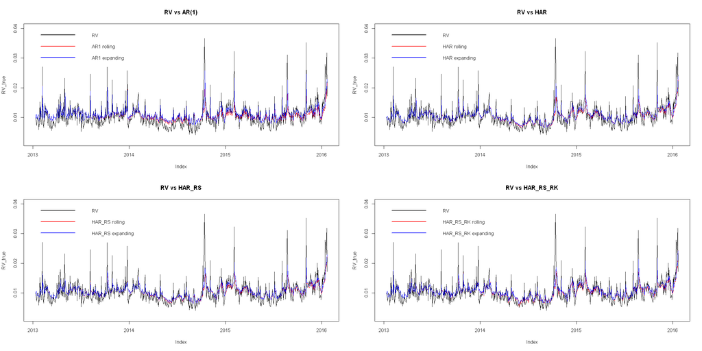

```r
options(repr.plot.width = 20, repr.plot.height = 10)
par(mfrow = c(2, 2))

plot.zoo(RV_true, lwd=1.5, col="black", ylim=c(0.002,0.04), main="RV vs AR(1)")
lines(zoo(AR1_roll, order.by=index(RV_true)), col="red")
lines(zoo(AR1_exp, order.by=index(RV_true)), col="blue")
legend("topleft", ncol = 1, legend = c('RV', 'AR1 rolling', 'AR1 expanding'), col = c('black', 'red', 'blue'), lwd = 2, bty = 'n')

plot.zoo(RV_true, lwd=1.5, col="black", ylim=c(0.002,0.04), main="RV vs HAR")
lines(zoo(HAR_roll, order.by=index(RV_true)), col="red")
lines(zoo(HAR_exp, order.by=index(RV_true)), col="blue")
legend("topleft", ncol = 1, legend = c('RV', 'HAR rolling', 'HAR expanding'), col = c('black', 'red', 'blue'), lwd = 2, bty = 'n')

plot.zoo(RV_true, lwd=1.5, col="black", ylim=c(0.002,0.04), main="RV vs HAR_RS")
lines(zoo(HAR_RS_roll, order.by=index(RV_true)), col="red")
lines(zoo(HAR_RS_exp, order.by=index(RV_true)), col="blue")
legend("topleft", ncol = 1, legend = c('RV', 'HAR_RS rolling', 'HAR_RS expanding'), col = c('black', 'red', 'blue'), lwd = 2, bty = 'n')

plot.zoo(RV_true, lwd=1.5, col="black", ylim=c(0.002,0.04), main="RV vs HAR_RS_RK")
lines(zoo(HAR_RS_RK_roll, order.by=index(RV_true)), col="red")
lines(zoo(HAR_RS_RK_exp, order.by=index(RV_true)), col="blue")
legend("topleft", ncol = 1, legend = c('RV', 'HAR_RS_RK rolling', 'HAR_RS_RK expanding'), col = c('black', 'red', 'blue'), lwd = 2, bty = 'n')
```

Regarding ARMA-GARCH forecasts, they are inappropriate because they overestimate volatility a lot. We also see that the forecasts are lagged which is visible over the whole horizon. This stems from the fact that GARCH is updating rather slowly. When we compare the two schemes (rolling vs expanding), rolling window naturally provides less lagged forecasts as old observations are discarded from memory.

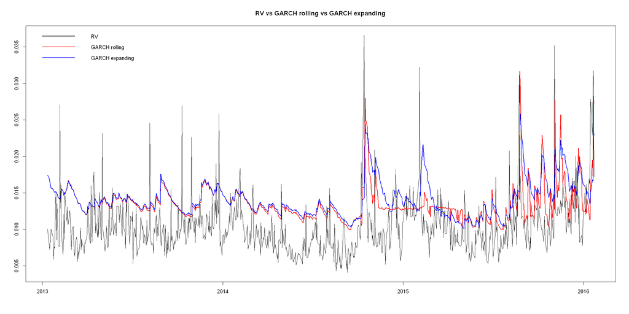

```r
plot.zoo(RV_true,xlab=NA,ylab=NA, main = "RV vs GARCH rolling vs GARCH expanding")
lines(zoo(sigma_GARCH_roll_for, order.by=index(RV_true)),col="red", lwd = 2)
lines(zoo(sigma_GARCH_exp_for, order.by=index(RV_true)),col="blue", lwd = 2)
legend("topleft", ncol = 1, legend = c('RV', 'GARCH rolling', 'GARCH expanding'), col = c('black', 'red', 'blue'), lwd = 2, bty = 'n')
```

Forecasts based on Realized GARCH contain outliers and therefore the trajectories look messy. We list the outliers below and account for them. For these values we decided to replace them with NAs. By doing this, we obtain clearer forecasts.

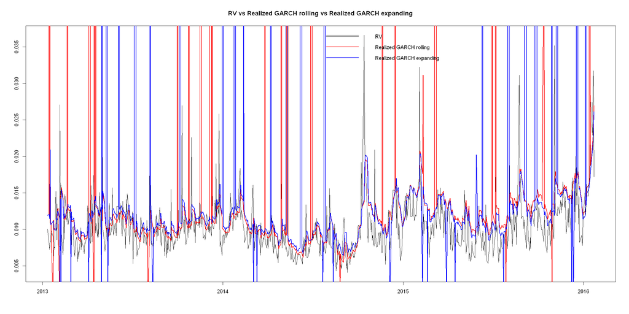

```r
plot.zoo(RV_true,xlab=NA,ylab=NA, main = "RV vs Realized GARCH rolling vs Realized GARCH expanding")
lines(zoo(sigma_real_GARCH_roll_for, order.by=index(RV_true)),col="red",lwd=2)
lines(zoo(sigma_real_GARCH_exp_for, order.by=index(RV_true)),col="blue",lwd=2)
legend("topright", ncol = 1, legend = c('RV', 'Realized GARCH rolling', 'Realized GARCH expanding'), col = c('black', 'red', 'blue'), lwd = 2, bty = 'n')
```

```r
boxplot.stats(sigma_real_GARCH_roll_for)
```

**$stats**

1. 0.00549182305363979

2. 0.00969846538216313

3. 0.0112884680211082

4. 0.0132814826325142

5. 0.0182912068275424

**$n**

750

**$conf**

1. 0.0110817514205964

2. 0.0114951846216199

**$out**

1. 0.274496818914574

2. 0.652129700009053

3. 0

4. 2.22275874948508e-162

5. 0.683497112253355

6. 0.200295873030391

7. 0

8. 0.397205864763213

9. 0.477530582089663

10. 0

11. 0.573003861449373

12. 0.314050608699701

13. 0.682663017560173

14. 0.660090049261733

15. 0.529375831852664

16. 0.266857168557136

17. 0.300702546951558

18. 0.393055604095776

19. 0.176243052271414

20. 0.299651292038397

21. 0

22. 0.0193835355895289

23. 0.0195405912871458

24. 0.019249996473712

25. 0.565596009785125

26. 0.209629465260825

27. 0.0207724389239253

28. 0.0204178851383063

29. 0.0192884502085015

30. 0.0311823803373441

31. 0.924923222381841

32. 0.242296942257335

33. 0.355984214309627

34. 0

35. 0.0509456115452893

36. 0

37. 0.250444916745856

38. 0.0380420734500119

39. 0.0187750387219536

40. 0.0215301576258036

41. 0.0225913094776347

42. 0.0244517781437766

43. 0.0269969709112047

```r
boxplot.stats(sigma_real_GARCH_exp_for)
```

**$stats**

1. 0.00644257971302632

2. 0.00987849093780138

3. 0.0112177087606948

4. 0.0131237590193698

5. 0.0179814802804921

**$n**

750

**$conf**

1. 0.0110304780725072

2. 0.0114049394488824

**$out**

1. 0.020950985171322

2. 0

3. 0

4. 2.22275874948508e-162

5. 0

6. 2.22275874948508e-162

7. 0.302205458162867

8. 0.196866229525599

9. 0

10. 0.29811644976903

11. 0.455776122850228

12. 0.694326199830592

13. 0

14. 0.398453267739941

15. 0.582893165891431

16. 0.208152386615153

17. 0.0392707068137461

18. 2.22275874948508e-162

19. 2.22275874948508e-162

20. 0.532185633962731

21. 0.232929980343493

22. 1.279028518275

23. 0

24. 0.319118702658109

25. 2.22275874948508e-162

26. 0.0185721818065853

27. 0.0199820339431264

28. 0.0202101377875393

29. 0.0198783225597864

30. 0.0180604584758301

31. 2.22275874948508e-162

32. 0.0202978293467401

33. 0.0203681178801586

34. 0.0198690389342413

35. 2.22275874948508e-162

36. 2.22275874948508e-162

37. 2.22275874948508e-162

38. 2.22275874948508e-162

39. 0.0202234289477426

40. 0.325782593839503

41. 2.22275874948508e-162

42. 0.699044467586008

43. 0.352124037240447

44. 0.747822194935182

45. 0.91033051143243

46. 0.597656347229089

47. 2.22275874948508e-162

48. 2.22275874948508e-162

49. 0.637241884753964

50. 0.41440531645862

51. 0.0181270604847341

52. 0.0208137991298341

53. 0.021888614355331

54. 0.0238634221799719

55. 0.0261696554367712

```r
sigma_real_GARCH_roll_for_clear <- sigma_real_GARCH_roll_for[sigma_real_GARCH_roll_for %in% boxplot.stats(sigma_real_GARCH_roll_for)$out] <- NA
sigma_real_GARCH_exp_for_clear <- sigma_real_GARCH_exp_for[sigma_real_GARCH_exp_for %in% boxplot.stats(sigma_real_GARCH_exp_for)$out] <- NA
```

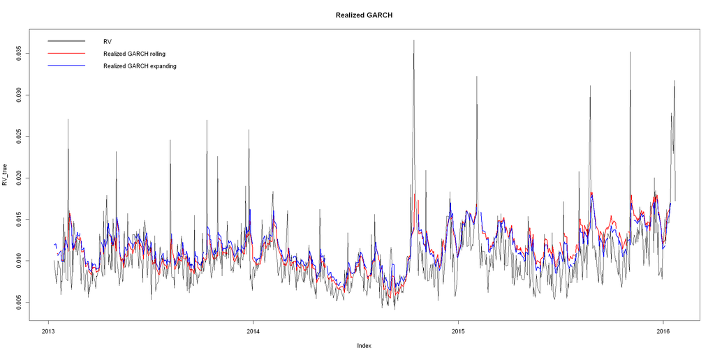

```r
plot.zoo(RV_true, col="black", main="Realized GARCH")
lines(zoo(sigma_real_GARCH_roll_for, order.by=index(RV_true)), col="red", lwd=2)
lines(zoo(sigma_real_GARCH_exp_for, order.by=index(RV_true)), col="blue", lwd=2)
legend("topleft", ncol = 1, legend = c('RV', 'Realized GARCH rolling', 'Realized GARCH expanding'), col = c('black', 'red', 'blue'), lwd = 2, bty = 'n')
```

By including RV in the volatility equation of GARCH, Realized GARCH estimates volatility better than ARMA-GARCH. This is in line with intuition and with model fit from previous section. We see that lagging nature of both approaches is still visible. However, the difference between the two approaches is now smaller compared to ARMA-GARCH. Nevertheless, Realized GARCH is deemed as an inaccurate forecast due overall overestimation of volatility.

### Forecast Errors

In this subsection, we plot forecast errors and conduct analysis on the performance of individual models. The goal is to select the best one.

We begin by computing loss functions and then run Diebold-Mariano tests utilizing the MSE loss function. Finally, we challange each model forecast with Mincer-Zarnowitz regression.

Forecast error is essentially the difference between the true value and the forecast. Naturally, we expect and would like to achieve the error to be zero. Therefore, we expect the plotted errors to oscillate around zero.

```r
AR1_roll_e <- RV_true - AR1_roll
AR1_exp_e <- RV_true - AR1_exp

HAR_roll_e <- RV_true - HAR_roll
HAR_exp_e <- RV_true - HAR_exp

HAR_RS_roll_e <- RV_true - HAR_RS_roll
HAR_RS_exp_e <- RV_true - HAR_RS_exp

HAR_RS_RK_roll_e <- RV_true - HAR_RS_RK_roll
HAR_RS_RK_exp_e <- RV_true - HAR_RS_RK_exp

sigma_GARCH_roll_for_e <- RV_true - sigma_GARCH_roll_for
sigma_GARCH_exp_for_e <- RV_true - sigma_GARCH_exp_for

sigma_real_GARCH_roll_for_e <- RV_true - sigma_real_GARCH_roll_for
sigma_real_GARCH_exp_for_e <- RV_true - sigma_real_GARCH_exp_for
```

Now, we are ready to plot all errors.

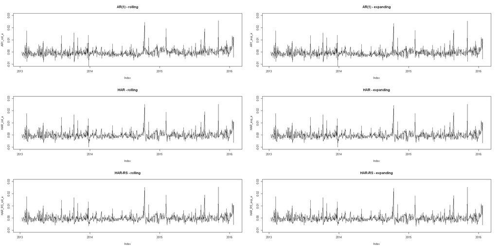

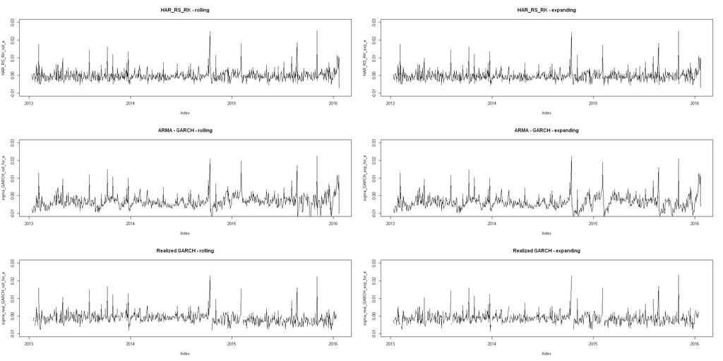

```r
options(repr.plot.width = 20, repr.plot.height = 10)
par(mfrow = c(3, 2))

plot.zoo(AR1_roll_e, ylim=c(-0.01, 0.03), main="AR(1) - rolling")
plot.zoo(AR1_exp_e, ylim=c(-0.01, 0.03), main="AR(1) - expanding")

plot.zoo(HAR_roll_e, ylim=c(-0.01, 0.03), main="HAR - rolling")
plot.zoo(HAR_exp_e, ylim=c(-0.01, 0.03), main="HAR - expanding")

plot.zoo(HAR_RS_roll_e, ylim=c(-0.01, 0.03), main="HAR-RS - rolling")
plot.zoo(HAR_RS_exp_e, ylim=c(-0.01, 0.03), main="HAR-RS - expanding")

plot.zoo(HAR_RS_RK_roll_e, ylim=c(-0.01, 0.03), main="HAR_RS_RK - rolling")
plot.zoo(HAR_RS_RK_exp_e, ylim=c(-0.01, 0.03), main="HAR_RS_RK - expanding")

plot.zoo(sigma_GARCH_roll_for_e, ylim=c(-0.01, 0.03), main="ARMA - GARCH - rolling")
plot.zoo(sigma_GARCH_exp_for_e, ylim=c(-0.01, 0.03), main="ARMA - GARCH - expanding")

plot.zoo(sigma_real_GARCH_roll_for_e, ylim=c(-0.01, 0.03), main="Realized GARCH - rolling")
plot.zoo(sigma_real_GARCH_exp_for_e, ylim=c(-0.01, 0.03), main="Realized GARCH - expanding")
```

When we look at the figures above, we indeed confirm our intuition about error means. We can also observe some common factors. For instance, there are regular occurrences of error spikes in all predictions. The errors overall look similar. ARMA-GARCH seems to perform worse due to higher volatility of errors. Realized GARCH performs better compared to ARMA-GARCH which is not surprising. However, just visual inspection is not enough. Therefore, we proceed with computation of loss functions.

Firstly, let's define MAE and MSE as:

$$MAE: \mathscr{L}(RV_{t+1},\hat{RV_{t+1|t})}=|RV_{t+h}-\hat{RV_{t+h|t}}|$$$$MSE: \mathscr{L}(RV_{t+1},\hat{RV_{t+1|t})}=(RV_{t+h}-\hat{RV_{t+h|t}})^2$$

Naturally, we would like to minizime these functions, which would imply higher accuracy of the predictions. Key difference between the two measures is the fact that MSE penalizes large forecast errors more compared to MAE. This is due to the power in the exponent. Let's compute them now.

```r
mean_errors <- matrix(ncol = 4, nrow = 6)
colnames(mean_errors) <- c('MAE - rolling', 'MAE - expanding', "MSE - rolling","MSE - expanding")
rownames(mean_errors) <- c('AR(1)', 'HAR', 'HAR-RS', "HAR_RS_RK", "ARMA - GARCH", "Realized GARCH" )

mean_errors[1, 1] <- mean(abs(AR1_roll_e), na.rm=TRUE)
mean_errors[1, 2] <- mean(abs(AR1_exp_e), na.rm=TRUE)
mean_errors[1, 3] <- mean(AR1_roll_e^2, na.rm=TRUE)
mean_errors[1, 4] <- mean(AR1_exp_e^2, na.rm=TRUE)

mean_errors[2, 1] <- mean(abs(HAR_roll_e), na.rm=TRUE)
mean_errors[2, 2] <- mean(abs(HAR_exp_e), na.rm=TRUE)
mean_errors[2, 3] <- mean(HAR_roll_e^2, na.rm=TRUE)
mean_errors[2, 4] <- mean(HAR_exp_e^2, na.rm=TRUE)

mean_errors[3, 1] <- mean(abs(HAR_RS_roll_e), na.rm=TRUE)
mean_errors[3, 2] <- mean(abs(HAR_RS_exp_e), na.rm=TRUE)
mean_errors[3, 3] <- mean(HAR_RS_roll_e^2, na.rm=TRUE)
mean_errors[3, 4] <- mean(HAR_RS_exp_e^2, na.rm=TRUE)

mean_errors[4, 1] <- mean(abs(HAR_RS_RK_roll_e), na.rm=TRUE)
mean_errors[4, 2] <- mean(abs(HAR_RS_RK_exp_e), na.rm=TRUE)
mean_errors[4, 3] <- mean(HAR_RS_RK_roll_e^2, na.rm=TRUE)
mean_errors[4, 4] <- mean(HAR_RS_RK_exp_e^2, na.rm=TRUE)

mean_errors[5, 1] <- mean(abs(sigma_GARCH_roll_for_e), na.rm=TRUE)
mean_errors[5, 2] <- mean(abs(sigma_GARCH_exp_for_e), na.rm=TRUE)
mean_errors[5, 3] <- mean(sigma_GARCH_roll_for_e^2, na.rm=TRUE)
mean_errors[5, 4] <- mean(sigma_GARCH_exp_for_e^2, na.rm=TRUE)

mean_errors[6, 1] <- mean(abs(sigma_real_GARCH_roll_for_e), na.rm=TRUE)
mean_errors[6, 2] <- mean(abs(sigma_real_GARCH_exp_for_e), na.rm=TRUE)
mean_errors[6, 3] <- mean(sigma_real_GARCH_roll_for_e^2, na.rm=TRUE)
mean_errors[6, 4] <- mean(sigma_real_GARCH_exp_for_e^2, na.rm=TRUE)

mean_errors
```

A matrix: 6 × 4 of type dbl

|  | MAE - rolling | MAE - expanding | MSE - rolling | MSE - expanding |
| --- | --- | --- | --- | --- |
| AR(1) | 0.002340386 | 0.002384033 | 1.177069e-05 | 1.159954e-05 |
| HAR | 0.002153854 | 0.002159233 | 1.079240e-05 | 1.059510e-05 |
| HAR-RS | 0.002135873 | 0.002139570 | 1.061613e-05 | 1.043689e-05 |
| HAR_RS_RK | 0.002125105 | 0.002133013 | 1.039594e-05 | 1.026605e-05 |
| ARMA - GARCH | 0.004111249 | 0.004529257 | 2.478558e-05 | 2.908638e-05 |
| Realized GARCH | 0.002466445 | 0.002453112 | 1.192140e-05 | 1.139080e-05 |

Firstly, let's mention that it might not make sense to compare MAE with MSE since they both have different construction. Therefore, we focus only on differences within each score. When looking at MAE, errors are minimized for HAR models - especially HAR_RS_RK performs the best. This conclusion holds for both prediction schemes. Should we choose between rolling and expanding window, HAR_RS_RK utilizing rolling window is our candidate. The worst performance is noted by ARMA-GARCH. Regarding MSE, the same conclusion can be reached. The only distinction is that error for HAR_RS_RK is lower under expanding scheme compared to rolling window.

Now, let's turn our focus to Diebold-Mariano test that check for differences in accuracy of forecasts. In the following section, we work with MSE loss. The logic is such that under the null hypothesis, the losses are the same and hence the models have statistically identical accuracy.

The tests centres around loss differential: $d_t=\mathscr{L_{1,t}}-\mathscr{L_{2,t}}$.

We assume that $d_t$ is stationary. The null of the DM test is $H^0: E[d_t]=0$

$DM - T = \frac{\sqrt{T}\bar{d}}{\sqrt{T}} \overset{a}{\sim} N(0,1)$,

where $\bar{d}=T^{-1}\Sigma_{t} d_t,\omega$ is its asymptotic variance. The $\omega$ is estimated as sample variance of $d_t$.

The null hypothesis is that the two methods have the same forecast accuracy. For alternative="less", the alternative hypothesis is that method 2 is less accurate than method 1. For alternative="greater", the alternative hypothesis is that method 2 is more accurate than method 1. For alternative="two.sided", the alternative hypothesis is that method 1 and method 2 have different levels of accuracy.

We begin testing each model and difference between the schemes.

```r
dm.test(AR1_roll_e, AR1_exp_e , alternative="two.sided", power=2)
dm.test(HAR_roll_e, HAR_exp_e , alternative="greater", power=2)
dm.test(HAR_RS_roll_e, HAR_RS_exp_e , alternative="greater", power=2)
dm.test(HAR_RS_RK_roll_e, HAR_RS_RK_exp_e , alternative="two.sided", power=2)
dm.test(sigma_GARCH_roll_for_e, sigma_GARCH_exp_for_e , alternative="less", power=2)
dm.test(na.omit(sigma_real_GARCH_roll_for_e), na.omit(sigma_real_GARCH_exp_for_e) , alternative="greater", power=2)
```

```
	Diebold-Mariano Test

data:  AR1_roll_eAR1_exp_e
DM = 0.8987, Forecast horizon = 1, Loss function power = 2, p-value =
0.3691
alternative hypothesis: two.sided
```

```
	Diebold-Mariano Test

data:  HAR_roll_eHAR_exp_e
DM = 1.7989, Forecast horizon = 1, Loss function power = 2, p-value =
0.03622
alternative hypothesis: greater
```

```
	Diebold-Mariano Test

data:  HAR_RS_roll_eHAR_RS_exp_e
DM = 1.8302, Forecast horizon = 1, Loss function power = 2, p-value =
0.03381
alternative hypothesis: greater
```

```
	Diebold-Mariano Test

data:  HAR_RS_RK_roll_eHAR_RS_RK_exp_e
DM = 1.225, Forecast horizon = 1, Loss function power = 2, p-value =
0.2209
alternative hypothesis: two.sided
```

```
	Diebold-Mariano Test

data:  sigma_GARCH_roll_for_esigma_GARCH_exp_for_e
DM = -6.2521, Forecast horizon = 1, Loss function power = 2, p-value =
3.4e-10
alternative hypothesis: less
```

```
	Diebold-Mariano Test

data:  na.omit(sigma_real_GARCH_roll_for_e)na.omit(sigma_real_GARCH_exp_for_e)
DM = 1.9044, Forecast horizon = 1, Loss function power = 2, p-value =
0.02865
alternative hypothesis: greater
```

AR(1) - indifferent

HAR - expanding window is more accurate

HAR_RS - expanding window is more accurate

HAR_RS_RK - indifferent

ARMA-GARCH - rolling window is more accurate

Realized GARCH - expanding window is more accurate

We now proceed further with DM testing. Once we have decided which scheme performs better, let's analyze models cross-sectionally. We choose expanding schemes were tests yielded indifferent results. Therefore, only time we consider rolling window is related to ARMA-GARCH specification. We proceed in following logic. We believe that HAR models are quite similar. Therefore, we choose HAR_RS_RK (our candidate from before) and compare it to other models outside HAR family. We assume that HAR_RS_RK would beat those. Then we do a quick rap battle within HAR family.

```r
dm.test(AR1_exp_e, HAR_RS_RK_exp_e , alternative="greater", power=2)
dm.test(sigma_GARCH_roll_for_e, HAR_RS_RK_exp_e , alternative="greater", power=2)
dm.test(na.omit(sigma_real_GARCH_exp_for_e) , HAR_RS_RK_exp_e , alternative="greater", power=2)
```

```
	Diebold-Mariano Test

data:  AR1_exp_eHAR_RS_RK_exp_e
DM = 4.9225, Forecast horizon = 1, Loss function power = 2, p-value =
5.259e-07
alternative hypothesis: greater
```

```
	Diebold-Mariano Test

data:  sigma_GARCH_roll_for_eHAR_RS_RK_exp_e
DM = 14.303, Forecast horizon = 1, Loss function power = 2, p-value <
2.2e-16
alternative hypothesis: greater
```

```
	Diebold-Mariano Test

data:  na.omit(sigma_real_GARCH_exp_for_e)HAR_RS_RK_exp_e
DM = 5.0574, Forecast horizon = 1, Loss function power = 2, p-value =
2.722e-07
alternative hypothesis: greater
```

Our assumptions were true and HAR_RS_RK beat all other models. This is actually true for any HAR model that could be substituted instead of HAR_RS_RK. Now, let's see which HAR model is the best.

```r
dm.test(HAR_exp_e, HAR_RS_exp_e , alternative="two.sided", power=2)
dm.test(HAR_exp_e, HAR_RS_RK_exp_e , alternative="two.sided", power=2)
dm.test(HAR_RS_exp_e, HAR_RS_RK_exp_e , alternative="two.sided", power=2)
```

```
	Diebold-Mariano Test

data:  HAR_exp_eHAR_RS_exp_e
DM = 1.4923, Forecast horizon = 1, Loss function power = 2, p-value =
0.136
alternative hypothesis: two.sided
```

```
	Diebold-Mariano Test

data:  HAR_exp_eHAR_RS_RK_exp_e
DM = 2.3027, Forecast horizon = 1, Loss function power = 2, p-value =
0.02157
alternative hypothesis: two.sided
```

```
	Diebold-Mariano Test

data:  HAR_RS_exp_eHAR_RS_RK_exp_e
DM = 1.6631, Forecast horizon = 1, Loss function power = 2, p-value =
0.09671
alternative hypothesis: two.sided
```

```r
dm.test(HAR_exp_e, HAR_RS_exp_e , alternative="greater", power=2)
dm.test(HAR_exp_e, HAR_RS_RK_exp_e , alternative="greater", power=2)
dm.test(HAR_RS_exp_e, HAR_RS_RK_exp_e , alternative="greater", power=2)
```

```
	Diebold-Mariano Test

data:  HAR_exp_eHAR_RS_exp_e
DM = 1.4923, Forecast horizon = 1, Loss function power = 2, p-value =
0.06802
alternative hypothesis: greater
```

```
	Diebold-Mariano Test

data:  HAR_exp_eHAR_RS_RK_exp_e
DM = 2.3027, Forecast horizon = 1, Loss function power = 2, p-value =
0.01078
alternative hypothesis: greater
```

```
	Diebold-Mariano Test

data:  HAR_RS_exp_eHAR_RS_RK_exp_e
DM = 1.6631, Forecast horizon = 1, Loss function power = 2, p-value =
0.04835
alternative hypothesis: greater
```

Finally, we see that HAR_RS_RK utilizing expanding window scheme beats all other models. Our initial choice of HAR_RS_RK turns out to be correct.

Before we reach final conclusion, let's conduct Mincer-Zarnowitz regressions. In this regression, we regress true values on forecasts, i.e.:

$$RV_{t+h}=\alpha+\beta\hat{RV_{t+h|t}}+\epsilon_t$$

for $h=1,2,...$

The null hypothesis: $H^0: \alpha = 0 \cup \beta=1$, which means that forecast matches true values. We conduct this regression for all models and all schemes. We comment on the results afterwards.

```r
MZ_AR1_roll<-lm(RV_true~AR1_roll)
summary(MZ_AR1_roll)

# The estimated coefficient is different from zero, but we want to test whether it is statistically different from 1. Therefore, we do following test.
MZ_AR1_roll_coef<-summary(MZ_AR1_roll)$coefficients
(MZ_AR1_roll_coef[2,"Estimate"]-1)/MZ_AR1_roll_coef[2,"Std. Error"]
# If the score is below -1.96 we can reject the null hypothesis that the coeffcient is 1.
```

```
Call:
lm(formula = RV_true ~ AR1_roll)

Residuals:
       Min         1Q     Median         3Q        Max
-0.0113777 -0.0019886 -0.0006381  0.0013066  0.0258682

Coefficients:
             Estimate Std. Error t value Pr(>|t|)
(Intercept) 0.0001048  0.0007175   0.146    0.884
AR1_roll    0.9717426  0.0661734  14.685   <2e-16 ***
---
Signif. codes:  0 '***' 0.001 '**' 0.01 '*' 0.05 '.' 0.1 ' ' 1

Residual standard error: 0.003429 on 748 degrees of freedom
Multiple R-squared:  0.2238,	Adjusted R-squared:  0.2227
F-statistic: 215.6 on 1 and 748 DF,  p-value: < 2.2e-16
```

-0.427020615697998

```r
MZ_AR1_exp<-lm(RV_true~AR1_exp)
summary(MZ_AR1_exp)

# The estimated coefficient is different from zero, but we want to test whether it is statistically different from 1. Therefore, we do following test.
MZ_AR1_exp_coef<-summary(MZ_AR1_exp)$coefficients
(MZ_AR1_exp_coef[2,"Estimate"]-1)/MZ_AR1_exp_coef[2,"Std. Error"]
# If the score is below -1.96 we can reject the null hypothesis that the coeffcient is 1.
```

```
Call:
lm(formula = RV_true ~ AR1_exp)

Residuals:
       Min         1Q     Median         3Q        Max
-0.0103425 -0.0019657 -0.0005819  0.0012014  0.0258096

Coefficients:
             Estimate Std. Error t value Pr(>|t|)
(Intercept) 0.0003618  0.0006435   0.562    0.574
AR1_exp     0.9163348  0.0572109  16.017   <2e-16 ***
---
Signif. codes:  0 '***' 0.001 '**' 0.01 '*' 0.05 '.' 0.1 ' ' 1

Residual standard error: 0.003359 on 748 degrees of freedom
Multiple R-squared:  0.2554,	Adjusted R-squared:  0.2544
F-statistic: 256.5 on 1 and 748 DF,  p-value: < 2.2e-16
```

-1.46240064037066

```r
MZ_HAR_roll<-lm(RV_true~HAR_roll)
summary(MZ_HAR_roll)

# The estimated coefficient is different from zero, but we want to test whether it is statistically different from 1. Therefore, we do following test.
MZ_HAR_roll_coef<-summary(MZ_HAR_roll)$coefficients
(MZ_HAR_roll_coef[2,"Estimate"]-1)/MZ_HAR_roll_coef[2,"Std. Error"]
# If the score is below -1.96 we can reject the null hypothesis that the coeffcient is 1.
```

```
Call:
lm(formula = RV_true ~ HAR_roll)

Residuals:
       Min         1Q     Median         3Q        Max
-0.0100372 -0.0019220 -0.0005642  0.0011408  0.0252770

Coefficients:
              Estimate Std. Error t value Pr(>|t|)
(Intercept) -0.0002670  0.0006322  -0.422    0.673
HAR_roll     1.0285853  0.0594152  17.312   <2e-16 ***
---
Signif. codes:  0 '***' 0.001 '**' 0.01 '*' 0.05 '.' 0.1 ' ' 1

Residual standard error: 0.003289 on 748 degrees of freedom
Multiple R-squared:  0.2861,	Adjusted R-squared:  0.2851
F-statistic: 299.7 on 1 and 748 DF,  p-value: < 2.2e-16
```

0.481111841862264

```r
MZ_HAR_exp<-lm(RV_true~HAR_exp)
summary(MZ_HAR_exp)

# The estimated coefficient is different from zero, but we want to test whether it is statistically different from 1. Therefore, we do following test.
MZ_HAR_exp_coef<-summary(MZ_HAR_exp)$coefficients
(MZ_HAR_exp_coef[2,"Estimate"]-1)/MZ_HAR_exp_coef[2,"Std. Error"]
# If the score is below -1.96 we can reject the null hypothesis that the coeffcient is 1.
```

```
Call:
lm(formula = RV_true ~ HAR_exp)

Residuals:
       Min         1Q     Median         3Q        Max
-0.0095600 -0.0018402 -0.0005536  0.0011466  0.0252850

Coefficients:
             Estimate Std. Error t value Pr(>|t|)
(Intercept) 0.0001268  0.0005896   0.215     0.83
HAR_exp     0.9741758  0.0543477  17.925   <2e-16 ***
---
Signif. codes:  0 '***' 0.001 '**' 0.01 '*' 0.05 '.' 0.1 ' ' 1

Residual standard error: 0.003256 on 748 degrees of freedom
Multiple R-squared:  0.3005,	Adjusted R-squared:  0.2995
F-statistic: 321.3 on 1 and 748 DF,  p-value: < 2.2e-16
```

-0.475166824149199

```r
MZ_HAR_RS_roll<-lm(RV_true~HAR_RS_roll)
summary(MZ_HAR_RS_roll)

# The estimated coefficient is different from zero, but we want to test whether it is statistically different from 1. Therefore, we do following test.
MZ_HAR_RS_roll_coef<-summary(MZ_HAR_RS_roll)$coefficients
(MZ_HAR_RS_roll_coef[2,"Estimate"]-1)/MZ_HAR_RS_roll_coef[2,"Std. Error"]
# If the score is below -1.96 we can reject the null hypothesis that the coeffcient is 1.
```

```
Call:
lm(formula = RV_true ~ HAR_RS_roll)

Residuals:
       Min         1Q     Median         3Q        Max
-0.0064942 -0.0018639 -0.0005332  0.0011283  0.0253774

Coefficients:
              Estimate Std. Error t value Pr(>|t|)
(Intercept) -0.0004045  0.0006222   -0.65    0.516
HAR_RS_roll  1.0424497  0.0584975   17.82   <2e-16 ***
---
Signif. codes:  0 '***' 0.001 '**' 0.01 '*' 0.05 '.' 0.1 ' ' 1

Residual standard error: 0.003261 on 748 degrees of freedom
Multiple R-squared:  0.298,	Adjusted R-squared:  0.2971
F-statistic: 317.6 on 1 and 748 DF,  p-value: < 2.2e-16
```

0.7256660038621

```r
MZ_HAR_RS_exp<-lm(RV_true~HAR_RS_exp)
summary(MZ_HAR_RS_exp)

# The estimated coefficient is different from zero, but we want to test whether it is statistically different from 1. Therefore, we do following test.
MZ_HAR_RS_exp_coef<-summary(MZ_HAR_RS_exp)$coefficients
(MZ_HAR_RS_exp_coef[2,"Estimate"]-1)/MZ_HAR_RS_exp_coef[2,"Std. Error"]
# If the score is below -1.96 we can reject the null hypothesis that the coeffcient is 1.
```

```
Call:
lm(formula = RV_true ~ HAR_RS_exp)

Residuals:
      Min        1Q    Median        3Q       Max
-0.006525 -0.001872 -0.000554  0.001124  0.025367

Coefficients:
              Estimate Std. Error t value Pr(>|t|)
(Intercept) -0.0001253  0.0005899  -0.212    0.832
HAR_RS_exp   0.9998552  0.0544962  18.347   <2e-16 ***
---
Signif. codes:  0 '***' 0.001 '**' 0.01 '*' 0.05 '.' 0.1 ' ' 1

Residual standard error: 0.003232 on 748 degrees of freedom
Multiple R-squared:  0.3104,	Adjusted R-squared:  0.3094
F-statistic: 336.6 on 1 and 748 DF,  p-value: < 2.2e-16
```

-0.00265772657042026

```r
MZ_HAR_RS_RK_roll<-lm(RV_true~HAR_RS_RK_roll)
summary(MZ_HAR_RS_RK_roll)

# The estimated coefficient is different from zero, but we want to test whether it is statistically different from 1. Therefore, we do following test.
MZ_HAR_RS_RK_roll_coef<-summary(MZ_HAR_RS_RK_roll)$coefficients
(MZ_HAR_RS_RK_roll_coef[2,"Estimate"]-1)/MZ_HAR_RS_RK_roll_coef[2,"Std. Error"]
# If the score is below -1.96 we can reject the null hypothesis that the coeffcient is 1.
```

```
Call:
lm(formula = RV_true ~ HAR_RS_RK_roll)

Residuals:
       Min         1Q     Median         3Q        Max
-0.0072951 -0.0018035 -0.0005654  0.0011544  0.0251748

Coefficients:
                 Estimate Std. Error t value Pr(>|t|)
(Intercept)    -0.0001769  0.0005903   -0.30    0.765
HAR_RS_RK_roll  1.0169561  0.0552046   18.42   <2e-16 ***
---
Signif. codes:  0 '***' 0.001 '**' 0.01 '*' 0.05 '.' 0.1 ' ' 1

Residual standard error: 0.003228 on 748 degrees of freedom
Multiple R-squared:  0.3121,	Adjusted R-squared:  0.3112
F-statistic: 339.4 on 1 and 748 DF,  p-value: < 2.2e-16
```

0.307150298202373

```r
MZ_HAR_RS_RK_exp<-lm(RV_true~HAR_RS_RK_exp)
summary(MZ_HAR_RS_RK_exp)

# The estimated coefficient is different from zero, but we want to test whether it is statistically different from 1. Therefore, we do following test.
MZ_HAR_RS_RK_exp_coef<-summary(MZ_HAR_RS_RK_exp)$coefficients
(MZ_HAR_RS_RK_exp_coef[2,"Estimate"]-1)/MZ_HAR_RS_RK_exp_coef[2,"Std. Error"]
# If the score is below -1.96 we can reject the null hypothesis that the coeffcient is 1.
```

```
Call:
lm(formula = RV_true ~ HAR_RS_RK_exp)

Residuals:
       Min         1Q     Median         3Q        Max
-0.0065584 -0.0017811 -0.0005941  0.0011070  0.0252116

Coefficients:
                Estimate Std. Error t value Pr(>|t|)
(Intercept)   -2.155e-05  5.684e-04  -0.038     0.97
HAR_RS_RK_exp  9.856e-01  5.221e-02  18.877   <2e-16 ***
---
Signif. codes:  0 '***' 0.001 '**' 0.01 '*' 0.05 '.' 0.1 ' ' 1

Residual standard error: 0.003203 on 748 degrees of freedom
Multiple R-squared:  0.3227,	Adjusted R-squared:  0.3218
F-statistic: 356.4 on 1 and 748 DF,  p-value: < 2.2e-16
```

-0.274943127771702

```r
MZ_sigma_GARCH_roll_for<-lm(RV_true~sigma_GARCH_roll_for)
summary(MZ_sigma_GARCH_roll_for)

# The estimated coefficient is different from zero, but we want to test whether it is statistically different from 1. Therefore, we do following test.
MZ_sigma_GARCH_roll_for_coef<-summary(MZ_sigma_GARCH_roll_for)$coefficients
(MZ_sigma_GARCH_roll_for_coef[2,"Estimate"]-1)/MZ_sigma_GARCH_roll_for_coef[2,"Std. Error"]
# If the score is below -1.96 we can reject the null hypothesis that the coeffcient is 1.
```

```
Call:
lm(formula = RV_true ~ sigma_GARCH_roll_for)

Residuals:
       Min         1Q     Median         3Q        Max
-0.0060865 -0.0023185 -0.0008545  0.0015007  0.0250937

Coefficients:
                     Estimate Std. Error t value Pr(>|t|)
(Intercept)          0.004161   0.000753   5.526 4.53e-08 ***
sigma_GARCH_roll_for 0.467162   0.054769   8.530  < 2e-16 ***
---
Signif. codes:  0 '***' 0.001 '**' 0.01 '*' 0.05 '.' 0.1 ' ' 1

Residual standard error: 0.003716 on 748 degrees of freedom
Multiple R-squared:  0.08864,	Adjusted R-squared:  0.08742
F-statistic: 72.75 on 1 and 748 DF,  p-value: < 2.2e-16
```

-9.72876370909057

```r
MZ_sigma_GARCH_exp_for<-lm(RV_true~sigma_GARCH_exp_for)
summary(MZ_sigma_GARCH_exp_for)

# The estimated coefficient is different from zero, but we want to test whether it is statistically different from 1. Therefore, we do following test.
MZ_sigma_GARCH_exp_for_coef<-summary(MZ_sigma_GARCH_exp_for)$coefficients
(MZ_sigma_GARCH_exp_for_coef[2,"Estimate"]-1)/MZ_sigma_GARCH_exp_for_coef[2,"Std. Error"]
# If the score is below -1.96 we can reject the null hypothesis that the coeffcient is 1.
```

```
Call:
lm(formula = RV_true ~ sigma_GARCH_exp_for)

Residuals:
      Min        1Q    Median        3Q       Max
-0.005790 -0.002343 -0.000774  0.001409  0.026066

Coefficients:
                     Estimate Std. Error t value Pr(>|t|)
(Intercept)         0.0045670  0.0007969   5.731 1.45e-08 ***
sigma_GARCH_exp_for 0.4197357  0.0557312   7.531 1.45e-13 ***
---
Signif. codes:  0 '***' 0.001 '**' 0.01 '*' 0.05 '.' 0.1 ' ' 1

Residual standard error: 0.003753 on 748 degrees of freedom
Multiple R-squared:  0.07049,	Adjusted R-squared:  0.06924
F-statistic: 56.72 on 1 and 748 DF,  p-value: 1.449e-13
```

-10.4118460939896

```r
MZ_sigma_real_GARCH_roll_for<-lm(RV_true~sigma_real_GARCH_roll_for)
summary(MZ_sigma_real_GARCH_roll_for)

# The estimated coefficient is different from zero, but we want to test whether it is statistically different from 1. Therefore, we do following test.
MZ_sigma_real_GARCH_roll_for_coef<-summary(MZ_sigma_real_GARCH_roll_for)$coefficients
(MZ_sigma_real_GARCH_roll_for_coef[2,"Estimate"]-1)/MZ_sigma_real_GARCH_roll_for_coef[2,"Std. Error"]
# If the score is below -1.96 we can reject the null hypothesis that the coeffcient is 1.
```

```
Call:
lm(formula = RV_true ~ sigma_real_GARCH_roll_for)

Residuals:
       Min         1Q     Median         3Q        Max
-0.0058941 -0.0018809 -0.0003903  0.0011775  0.0246632

Coefficients:
                           Estimate Std. Error t value Pr(>|t|)
(Intercept)               0.0023407  0.0005671   4.128  4.1e-05 ***
sigma_real_GARCH_roll_for 0.7008346  0.0487833  14.366  < 2e-16 ***
---
Signif. codes:  0 '***' 0.001 '**' 0.01 '*' 0.05 '.' 0.1 ' ' 1

Residual standard error: 0.003207 on 705 degrees of freedom
  (43 observations deleted due to missingness)
Multiple R-squared:  0.2265,	Adjusted R-squared:  0.2254
F-statistic: 206.4 on 1 and 705 DF,  p-value: < 2.2e-16
```

-6.13253794732041

```r
MZ_sigma_real_GARCH_exp_for<-lm(RV_true~sigma_real_GARCH_exp_for)
summary(MZ_sigma_real_GARCH_exp_for)

# The estimated coefficient is different from zero, but we want to test whether it is statistically different from 1. Therefore, we do following test.
MZ_sigma_real_GARCH_exp_for_coef<-summary(MZ_sigma_real_GARCH_exp_for)$coefficients
(MZ_sigma_real_GARCH_exp_for_coef[2,"Estimate"]-1)/MZ_sigma_real_GARCH_exp_for_coef[2,"Std. Error"]
# If the score is below -1.96 we can reject the null hypothesis that the coeffcient is 1.
```

```
Call:
lm(formula = RV_true ~ sigma_real_GARCH_exp_for)

Residuals:
       Min         1Q     Median         3Q        Max
-0.0063756 -0.0017709 -0.0004134  0.0011170  0.0245373

Coefficients:
                          Estimate Std. Error t value Pr(>|t|)
(Intercept)              0.0012395  0.0006288   1.971   0.0491 *
sigma_real_GARCH_exp_for 0.7919362  0.0540346  14.656   <2e-16 ***
---
Signif. codes:  0 '***' 0.001 '**' 0.01 '*' 0.05 '.' 0.1 ' ' 1

Residual standard error: 0.003149 on 693 degrees of freedom
  (55 observations deleted due to missingness)
Multiple R-squared:  0.2366,	Adjusted R-squared:  0.2355
F-statistic: 214.8 on 1 and 693 DF,  p-value: < 2.2e-16
```

-3.8505656422376

## 4. Summary

In this empirical project we try to model realized volatility of Archer-Daniels-Midland Co. (ADM) stock and evaluate predictive ability of the models, six in total - AR(1), HAR, HAR_RS, HAR_RS_RK, ARMA-GARCH and Realized GARCH - to provide future estimates of volatility.

We compare in-sample fits corresponding to each model and elaborate by visual inspection. The best in-sample estimation performance is reached by the HAR family models - their fiited values mimic the actual realized volatility more accurately than AR(1) or GARCH models. Therefore, due to statistical significance of estimated coefficients and higherst $R^2$, HAR_RS_RK is potential candidate for forecasting.

To predict volatility, we divide the sample into two parts - training and testing sets of equal length - and provide forecasts utilizing all six models from the prior section of this project. Additionally, for each predition we use two different approaches - rolling window and expanding window. The out-of-sample forecasting performance of the models is tested by comparison of mean square errors (MSE) and mean absolute errors (MAE). We proceed to distinguish between two model forecasts using Diebold-Mariano test and then test individual forecasts using Mincer-Zarnowitz regression. HAR models are shown to outperform AR(1) and GARCH models also in out-of-sample forecasts no matter the scheme (rolling vs expanding). The MAE and MSE are both minimized for HAR_RS_RK in particular for both expanding and rolling windows, suggesting that HAR_RS_RK estimates the volatility most precisely among all six models. This is then confirmed by Diebold-Mariano tests as well, that compare the models pairwise, HAR_RS_RK turned out to be the best performer. Finally, we employed the Mincer-Zarnowitz regression to examine forecast accuracy of all single model forecasts. Results of the Mincer-Zarnowitz regressions suggest that $R^2$ is the highest for HAR_RS_RK expanding window approach, which indicates highest accuracy among all considered specifications. All in all, after taking into account outcomes of various methods used for assessing the forecasting accuracy, results lead us to conclusion that the HAR_RS_RK is the best choice to model and predict volatility of ADM stock.